# Rapport projet AC04

Abou Ghalia Mostafa, Azzouz Ilian, Eddeghai Yasmine, Guilbert–Ly Anne-Soline

06/06/2022

# Projet AC04 - Régression linéaire

[figure not shown]

## AC04 P22

Abou Ghalia Mostafa (20%)

Azzouz Ilian (20%)

Eddeghai Yasmine (30%)

Guilbert–Ly Anne-Soline (30%)

# I. Modèle de régression linéaire simple Gaussien et estimation des paramètres

## I.1. Modèle

On a $n$ couples $(x_1, Y_1), ..., (x_n, Y_n)$ avec $x_i \in \mathbb{R}$ et $Y_i$ v.A. réelle de réalisation $y_i$.

On suppose $\mathbb{E}(Y_i) = a + bx_i \forall i = 1,.., n$. Donc on a le modèle de régression linéaire suivant : $Y_i = a + bx_i + \epsilon_i,$ avec $\mathbb{E}(\epsilon_i) = 0, \forall i \in \{1,.., n\}$, les $(\epsilon_i)_i$ sont les bruits.

On suppose les erreurs indépendantes, normales, et de même variance $\sigma²$.

Donc $\epsilon_1, ...,n \overset{\mathrm{iid}}{\sim}\mathcal{N}(0,\,\sigma^{2})$. Donc $\forall i \in \{1, ..., n\}, Y_i {\sim}\mathcal{N}(a+bx_i, \sigma²)$

Et les paramètre du modèle sont : $a, b$ réels et $\sigma² > 0$

## I.2. Estimation

Les EMV $\hat{a}, \hat{b}, \hat{\sigma}²_{MV}$ sont calculées à partir de moyennes, variance, … Et on calcul à partir de ces résultats les estimations $\hat{Y}_i$, et $\hat{\epsilon}_i$

## I.3. Propriétés des estimateurs et I.C.

Les estimateurs de $a$, $b$, et $\sigma$ sont sans biais. Leurs lois sont connues et, celles de a et b sont gaussiennes. => On peut obtenir des fonctions pivotales exactes pour $a$ et $b$ pour déterminer des intervalles de confiance.

# II. Données simulées

## (Q1) Simulation de v.a

```r
a0 <- round(runif(1, 3, 15), 2)
b0 <- round(runif(1, 1, 5), 2)
s0 <- round(runif(1, 1, 3), 2)
```

### (Q1a) (Q1b) Simulation de $n$ v.a. iid de loi uniforme et de v.a. modèle régréssion linéaire Gaussien

Pour simuler $n$ variables aléatoires indépendantes et identiquement distribuées $X_1, ..., X_n$, nous utilisons la fonction `sample` pour prendre une valeur $n$ entre 200 et 1000. Ensuite, les $X_1, ..., X_n$ qui suivent la loi uniforme sur $[0,5]$ sont simulées avec la fonction `runif`. Pour simuler $n$ variables aléatoires indépendantes et identiquement distribuées $Y_1, ..., Y_n$ qui suivent la loi Gaussien de paramètres $a = a_0, b = b_0$ et $\sigma² = s_0$, nous pouvons utiliser la fonction `rnorm`.

```r
n <- sample(800, 1) + 200

generate_sample <- function(n) {
    xi <- runif(n, 0, 5) # Vector of (xi), i=1..n
    Yi <- rnorm(n, a0 + b0 * xi, sqrt(s0))
    # rnorm takes mean and standard deviation, not variance

    return(list(xi = xi, Yi = Yi))
}

sample <- generate_sample(n)
xi <- sample$xi
Yi <- sample$Yi
```

## (Q2) Graphique de nuage de points

Pour représenter le graphique, nous utilisons les fonctions `plot` pour le nuage de points $(x_i, y_i)_{1\le i\le n}$, et `abline` pour la droite de régression d’équation $y = a+bx$ avec $a=a_0, b=b_0$ et $\sigma²=s_0$.

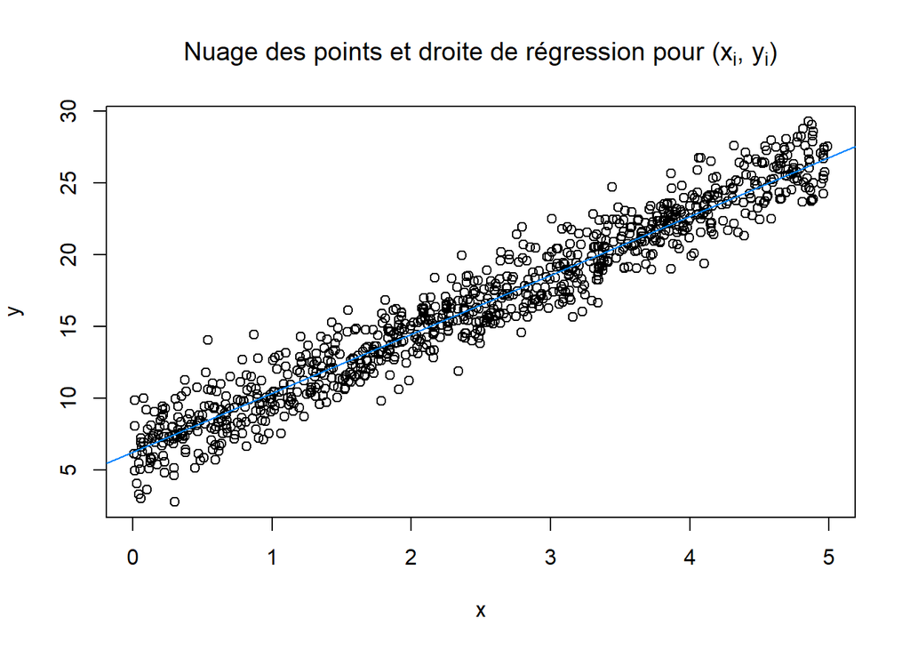

```r
plot(xi, Yi, main = TeX("Nuage des points et droite de régression pour ($x_i$, $y_i$)"), xlab = TeX("x"), ylab = TeX("y"))
abline(a0, b0, col = "#0084ff")
```

## (Q3) Fonctions “b_estim”, “a_estim” et “sigma_estim”

Nous pouvons déduire les fonctions d’après les formules de la partie 1.2. pour les estimateurs sans biais de $a$ et $b$, et de la partie 1.3. pour celui de $s_0$.

```r
b_estim <- function(xi, Yi) {
    x_bar <- mean(xi)
    Y_bar <- mean(Yi)

    SxY <- mean((Yi - Y_bar) * (xi - x_bar))
    sx2 <- mean((xi - x_bar)^2)

    return(SxY / sx2)
}

a_estim <- function(xi, Yi) {
    Y_bar <- mean(Yi)
    b_hat <- b_estim(xi, Yi)
    x_bar <- mean(xi)

    return(Y_bar - b_hat * x_bar)
}

sigma_estim <- function(xi, Yi) {
    a_hat <- a_estim(xi, Yi)
    b_hat <- b_estim(xi, Yi)

    return(mean((Yi - a_hat - b_hat * xi)^2))
}
```

## (Q4) Estimation de $a$, $b$ et $\sigma^2$

On appelle les fonctions qu’on vient de créer, avec en paramètres les variables aléatoires $x$ et $y$ générées plus haut.

```r
a_hat <- a_estim(xi, Yi)
b_hat <- b_estim(xi, Yi)
sig_hat <- sigma_estim(xi, Yi)

print(paste("a^ =", a_hat))
```

```
## [1] "a^ = 6.13353407808861"
```

```r
print(paste("b^ =", b_hat))
```

```
## [1] "b^ = 4.16666614056643"
```

```r
print(paste("s^ =", sig_hat))
```

```
## [1] "s^ = 2.19073429526655"
```

## (Q5) Nuage de points de $y=a_0 + b_0$

Nous utilisons les mêmes fonctions que précédemment pour afficher le graphique. Nous affichons le nuage de points $(x_i, y_i)_{1\le i\le n}$ simulés en (Q1a) et (Q1b), la droite de régression $y = a_0 + b_0 x$ en rouge, ainsi que la droite des moindres carrés $y = \hat{a} + \hat{b} x$ en bleu. La fonction `abline` prend en argument l’ordonnée à l’origine et la pente.

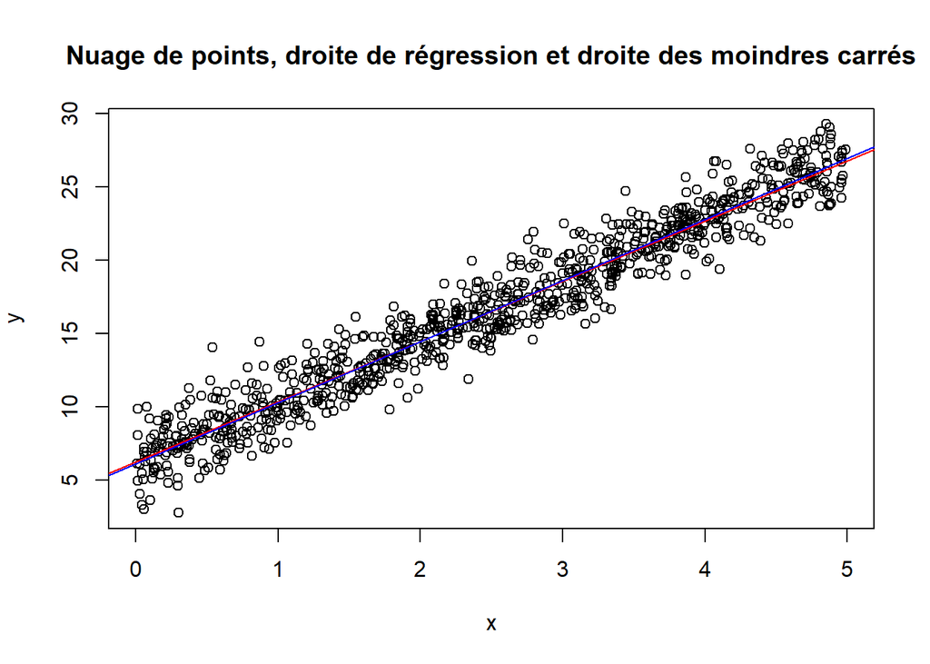

```r
plot(xi, Yi, main = "Nuage de points, droite de régression et droite des moindres carrés", xlab = TeX("x"), ylab = TeX("y"))
abline(a0, b0, col = "red")
abline(a_hat, b_hat, col = "blue")
```

## (Q6) Vecteur des résidus $ê_i$

La formule suivante permet de calculer le vecteur des résidus : $ê_i = Y_i - Ŷ_i$. Pour vérifier les propriétés des résidus, nous sommons tous les résidus $ê_i$ de $0$ à $n$.

```r
print(mean(Yi) - (a_hat + b_hat * mean(xi))) # y_bar = a_hat - b_hat * x_bar
```

```
## [1] 0
```

```r
e_hat <- Yi - (a_hat + b_hat * xi) # residus
print(sum(e_hat)) # Somme nulle
```

```
## [1] -6.608047e-13
```

## (Q7) Appartenance $(\overline{x},\overline{y})$

```r
resultat <- mean(Yi) - a0 + b0 * mean(xi)
print(resultat)
```

```
## [1] 20.3948
```

```r
resultat == 0
```

```
## [1] FALSE
```

```r
# ou
all.equal(a0 + b0 * mean(xi), mean(Yi))
```

```
## [1] "Mean relative difference: 0.002064248"
```

## (Q8) Correspondances

Nous fournissons la correspondance poru les paramètres $a$, $b$, et les résidus $ê_i$. Nous comparons encore une fois les valeurs avec la fonction `all.equal`. Chaque appel renvoie `True` ce qui montre que nos calculs sont justes par rapport à ceux de la fonction `lm` et `summary`.

```r
reg <- lm(Yi ~ 1 + xi) # stockage de la fonction linear model
summary(reg)
```

```
##
## Call:
## lm(formula = Yi ~ 1 + xi)
##
## Residuals:
##     Min      1Q  Median      3Q     Max
## -4.6265 -1.0642 -0.0623  0.8871  5.6834
##
## Coefficients:
##             Estimate Std. Error t value Pr(>|t|)
## (Intercept)  6.13353    0.09920   61.83   <2e-16 ***
## xi           4.16667    0.03475  119.91   <2e-16 ***
## ---
## Signif. codes:  0 '***' 0.001 '**' 0.01 '*' 0.05 '.' 0.1 ' ' 1
##
## Residual standard error: 1.482 on 901 degrees of freedom
## Multiple R-squared:  0.941,  Adjusted R-squared:  0.941
## F-statistic: 1.438e+04 on 1 and 901 DF,  p-value: < 2.2e-16
```

```r
lm_coef_a <- summary(reg)$coefficients[1, 1]
all.equal(lm_coef_a, a_hat)
```

```
## [1] TRUE
```

```r
lm_coef_b <- summary(reg)$coefficients[2, 1]
all.equal(lm_coef_b, b_hat)
```

```
## [1] TRUE
```

```r
all.equal(mean(e_hat), mean(summary(reg)$residuals))
```

```
## [1] TRUE
```

## (Q9) Illustration graphique la convergence

```r
a_hats <- c()
b_hats <- c()

nMax <- 50000
Ns <- seq(200, nMax, 100)

for (n in Ns) {
    s <- generate_sample(n)

    a_hats <- c(a_hats, a_estim(s$xi, s$Yi))
    b_hats <- c(b_hats, b_estim(s$xi, s$Yi))
}
```

Nous faisons la même chose pour $\hat{b}$.

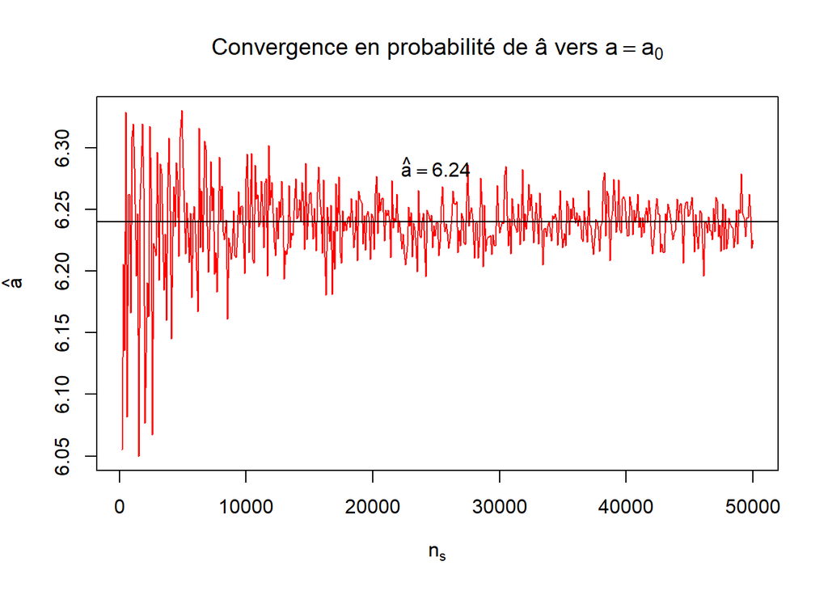

```r
plot(Ns, a_hats,
    type = "l", col = "red",
    main = TeX("Convergence en probabilité de â vers $a = a_0$"),
    xlab = TeX("$n_s$"), ylab = TeX("\\hat{a}")
)
abline(h = a0)
text(nMax - nMax / 2, a0 + abs(a0 - max(a_hats)) * 0.5, TeX(paste("$\\hat{a} = ", a0)),
    col = "black"
)
```

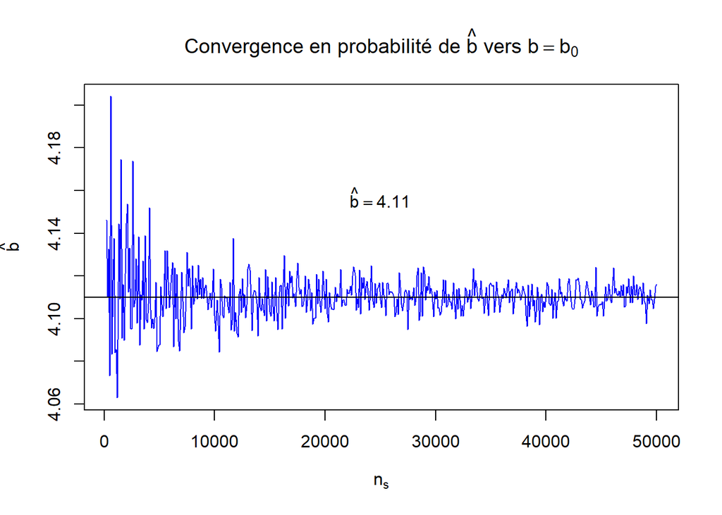

```r
plot(Ns, b_hats,
    type = "l", col = "blue",
    main = TeX("Convergence en probabilité de $\\hat{b}$ vers $b = b_0$"),
    xlab = TeX("$n_s$"), ylab = TeX("\\hat{b}")
)
abline(h = b0)
text(nMax - nMax / 2, b0 + abs(b0 - max(b_hats) ) * 0.5 , TeX(paste("$\\hat{b} = ", b0)),
    col = "black"
)
```

## (Q10) Illustration de la formule

Nous générons 150 fois la fonction pivotale de a, le résultat est utilisé pour afficher l’histogramme à l’aide de la fonction `hist` et nous générons la courbe de la fonction de densité de la loi student avec un $n-2$ degré de iberté à l’aide de la fonction `curve`.

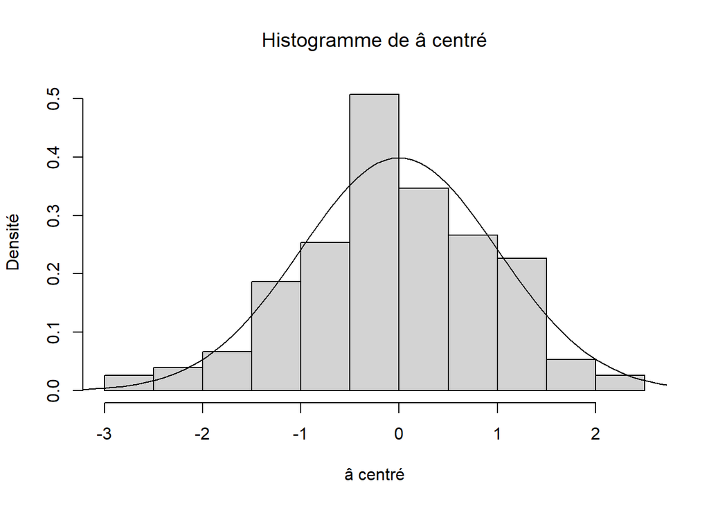

```r
n <- 10000 # Un peu boosté pour que ce soit plus obvious
f <- function(n) {
    s <- generate_sample(n)

    a_hat <- a_estim(s$xi, s$Yi)
    sig_hat <- sigma_estim(s$xi, s$Yi)
    x_bar <- mean(s$xi)
    sx2 <- mean((s$xi - x_bar)^2)

    return((a_hat - a0) / sqrt(sig_hat / n * (1 + x_bar^2 / sx2)))
}
centered_a_hat <- replicate(150, f(n))

hist(centered_a_hat, freq = FALSE,
    main = TeX("Histogramme de â centré"),
    xlab = TeX("â centré"),
    ylab = TeX("Densité")

)
curve(dt(x, n - 2),
    from = floor(min(centered_a_hat) - 1),
    to = floor(max(centered_a_hat) + 1),
    add = TRUE,
) # dt (fonction de densité de proba de Student) prends en argument
```

## (Q11) Fonctions “gen_IC_a”, “gen_IC_b” et “gen_IC_s”

Pour chaque paramètre, nous crééons une fonction qui génère les intervalles de confiance. Chaque fonction retourne un vecteur contenant la valeur maximale et minimale de l’intervalle de confiance.

```r
gen_IC_a <- function(s, alpha) {
    n <- length(s$xi)

    a_hat <- a_estim(s$xi, s$Yi)

    t <- qt(1 - alpha / 2, n - 2)

    s_hat <- sigma_estim(s$xi, s$Yi)
    x_bar <- mean(s$xi)
    sx2 <- mean((s$xi - x_bar)^2)

    sqr <- sqrt(s_hat / n * (1 + x_bar^2 / sx2))

    return(c(a_hat - t * sqr, a_hat + t * sqr))
}

gen_IC_b <- function(s, alpha) {
    n <- length(s$xi)

    b_hat <- b_estim(s$xi, s$Yi)

    t <- qt(1 - alpha / 2, n - 2)
    s_hat <- sigma_estim(s$xi, s$Yi)
    sx2 <- mean((s$xi - mean(s$xi))^2)

    sqr <- sqrt(s_hat / (n * sx2))
    return(c(b_hat - t * sqr, b_hat + t * sqr))
}

gen_IC_s <- function(s, alpha) {
    n <- length(s$xi)
    s_hat <- sigma_estim(s$xi, s$Yi)

    denom_min <- qchisq(1 - alpha / 2, n - 2)

    denom_max <- qchisq(alpha / 2, n - 2)

    min <- ((n - 2) * s_hat) / denom_min
    max <- ((n - 2) * s_hat) / denom_max

    return(c(min, max))
}
```

## (Q12) Intervalles de confiance pour $a$, $b$ et $\sigma^2$

Nous appelons les fonctions gen_IC_a, gen_IC_b et gen_IC_s 100 fois avec un niveau de signification $\alpha = 0.05$

```r
# Quelle valeur pour alpha ?
IC_a <- replicate(100, gen_IC_a(sample, 0.05))
IC_b <- replicate(100, gen_IC_b(sample, 0.05))
IC_s <- replicate(100, gen_IC_s(sample, 0.05))
```

## (Q13) Visualisation des intervalles de confiance

On affiche les intervalles de confiance pour l’estimateur de $a$, celui de $b$ et de $\sigma$.

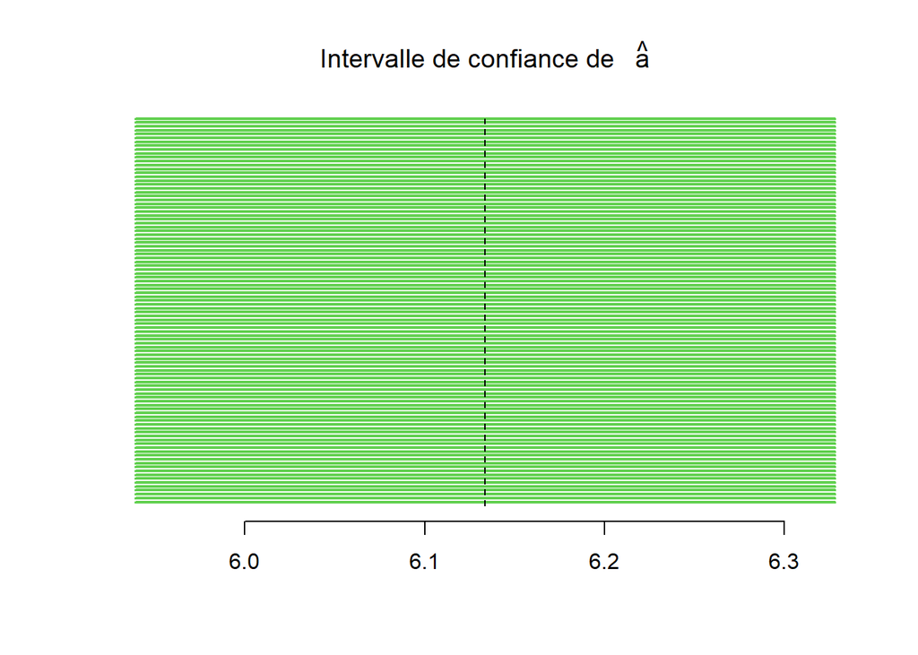

```r
source("utils.R")
plot_ICs(IC_a, a_hat, main = TeX("Intervalle de confiance de $\\ \\hat{a}$"))
```

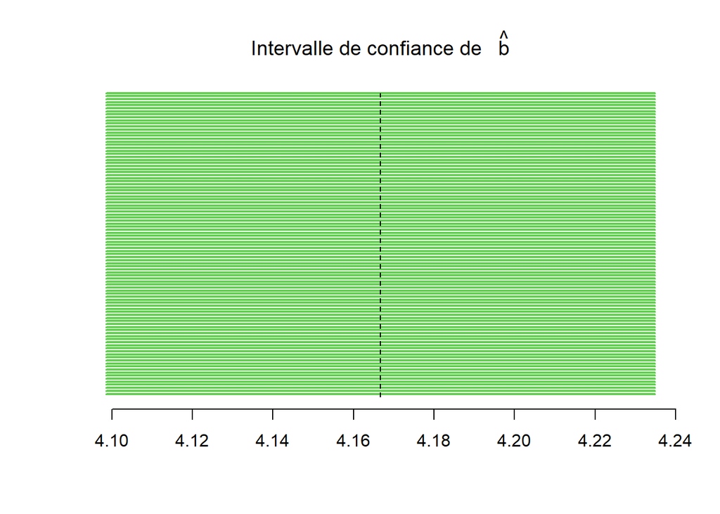

```r
plot_ICs(IC_b, b_hat, main = TeX("Intervalle de confiance de $\\ \\hat{b}$"))
```

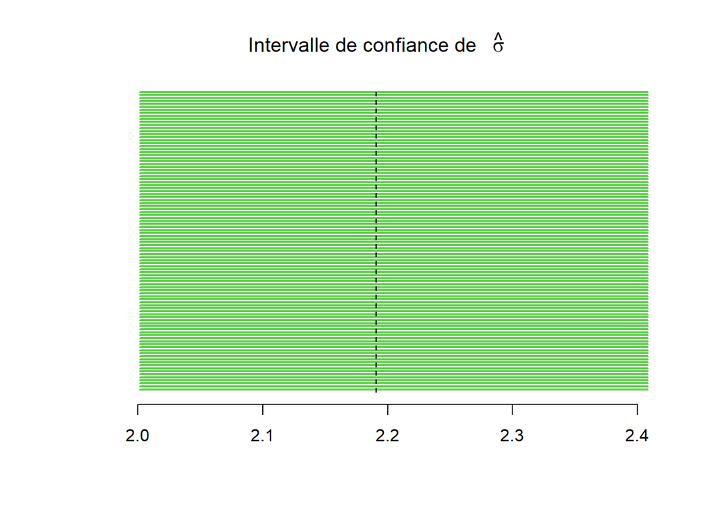

```r
plot_ICs(IC_s, sig_hat, main = TeX("Intervalle de confiance de $\\ \\hat{\\sigma}$"))
```

Nous pouvons constater que l’intervalle de confiance de $\hat{b}$ est le plus précis des trois car son intervalle de tolérance est à 0.14, tandis que ceux de $\hat{a}$ et $\hat{\sigma}$ sont respectivement de 0.39 et 0.43. Ainsi, le calcul de l’estimateur de b est plus exact que ceux pour l’estimateur de a et de sigma.

# III. Jeu de données réelles “Real_Data”

Nous choisissons le jeu de données “bodyfat” dont la premiere colonne représente le taux de masse grasse dans le corps (en %), la seconde, le taux de masse grasse dans les triceps, la troisième, le taux de masse grasse dans les cuisses, et la dernière le taux de masse grasse dans les bras. Nous chercherons d’abord à savoir lequel de ces 3 taux a le plus d’influence sur celui dans le corps. Et nous étudierons ensuite à quel point cette variable explique la taux de masse grasse corporelle.

```r
real_data <- read.table("bodyfat.dat", header = TRUE)
```

## III.1. Quelques éléments de statistique descriptive

### (Q14) Motivation du choix et statistique descriptive

Pour choisir une paire de variables qui convient, nous étudions, pour chacune des paires, le graphique en nuage de points, la droite de régression d’équation $y = a_0 + b_0x$, ainsi que le coefficient de corrélation de Pearson.

Dans chacun des cas, nous prenons en tant que variable à expliquer, le taux de gras corporel, et en tant que variable explicative, le taux de gras dans les triceps, les cuisses, ou les bras.

D’après les graphiques, nous constatons que le couple (xi_midarm, yi_fat) n’est pas un bon choix car la relation de linéarité n’est pas très bien marquée. Leur coefficient de corrélation nous confirme que nous n’allons pas choisir ce couple car il est trop proche de 0 comparé aux autres.

Pour faire le choix entre le couple (xi_triceps, yi_fat) et (xi_thigh, yi_fat), nous allons prendre celui dont le coefficient de corrélation est le plus proche de 1 : c’est le couple (xi_thigh, yi_fat).

Ce choix semble cohérent car c’est généralement dans cette partie du corps humain qu’est stocké la majorité de la masse grasse.

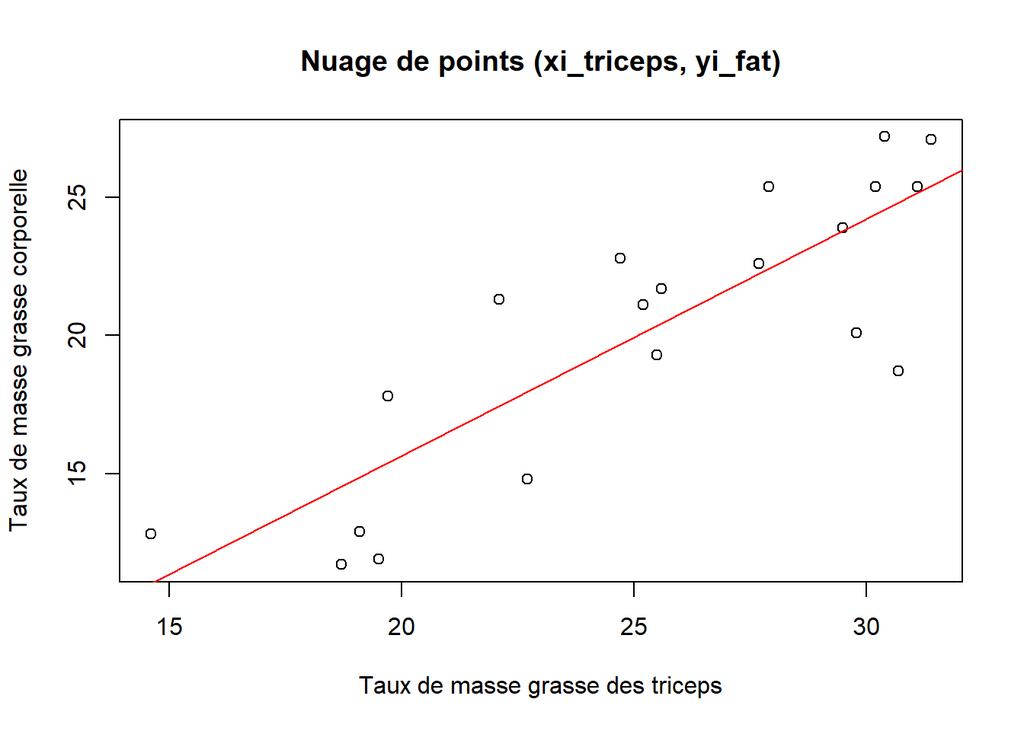

```r
yi_fat <- real_data$Fat
xi_triceps <- real_data$Triceps
xi_thigh <- real_data$Thigh
xi_midarm <- real_data$Midarm

plot(xi_triceps, yi_fat,
    main = "Nuage de points (xi_triceps, yi_fat)",
    xlab = "Taux de masse grasse des triceps",
    ylab = "Taux de masse grasse corporelle"
)
abline(a_estim(xi_triceps, yi_fat), b_estim(xi_triceps, yi_fat), col = "red")
```

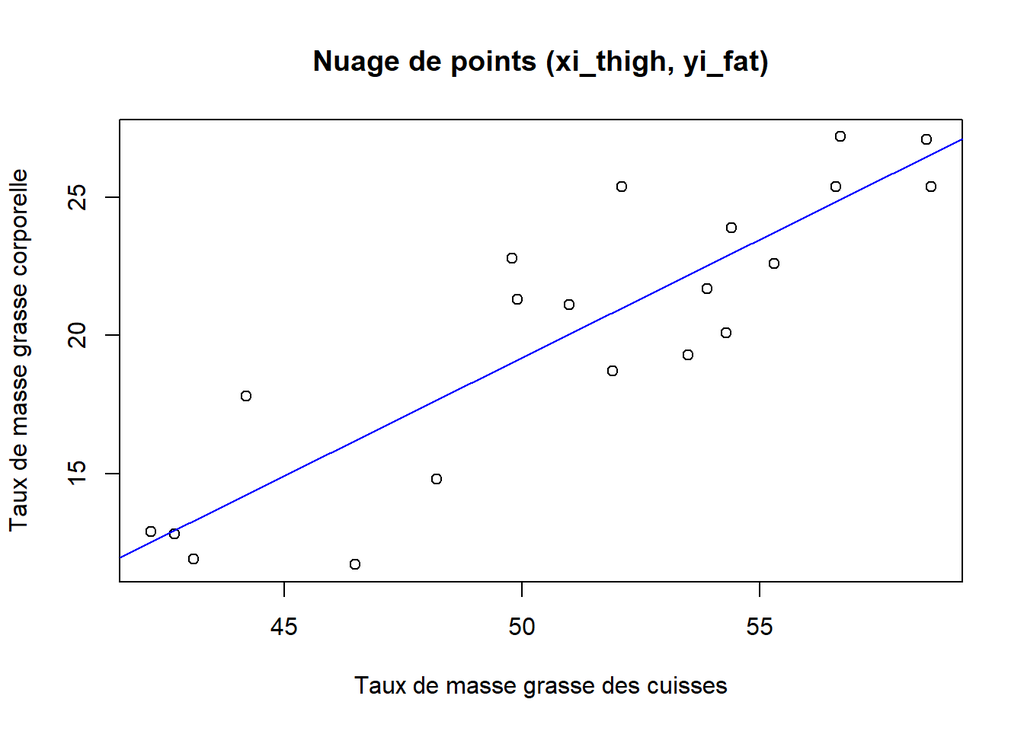

```r
plot(xi_thigh, yi_fat,
    main = "Nuage de points (xi_thigh, yi_fat)",
    xlab = "Taux de masse grasse des cuisses",
    ylab = "Taux de masse grasse corporelle"
)
abline(a_estim(xi_thigh, yi_fat), b_estim(xi_thigh, yi_fat), col = "blue")
```

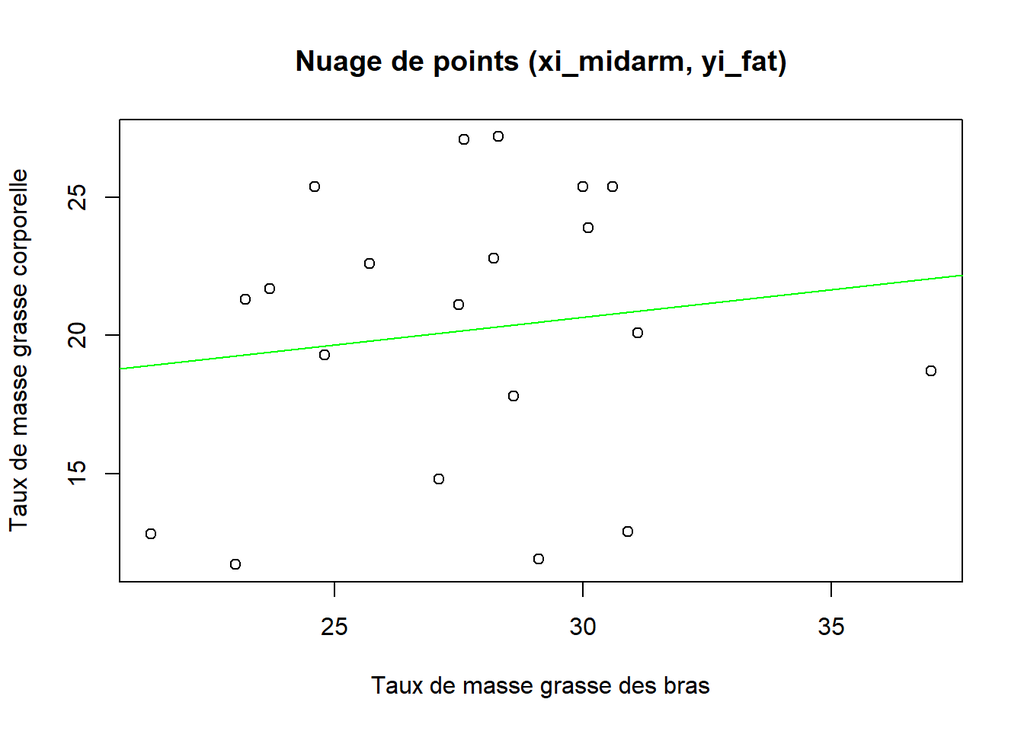

```r
plot(xi_midarm, yi_fat,
    main = "Nuage de points (xi_midarm, yi_fat)",
    xlab = "Taux de masse grasse des bras",
    ylab = "Taux de masse grasse corporelle"
)
abline(a_estim(xi_midarm, yi_fat), b_estim(xi_midarm, yi_fat), col = "green")
```

```r
# Coefficient de corrélation de Pearson :
coef_cor_triceps <- cor(xi_triceps, yi_fat, method = "pearson")
coef_cor_thigh <- cor(xi_thigh, yi_fat, method = "pearson")
coef_cor_midarm <- cor(xi_midarm, yi_fat, method = "pearson")

print("coefficient de corrélation pour xi_triceps et yi_fat : ")
```

```
## [1] "coefficient de corrélation pour xi_triceps et yi_fat : "
```

```r
print(coef_cor_triceps)
```

```
## [1] 0.8432654
```

```r
print("coefficient de corrélation pour xi_thigh et yi_fat :")
```

```
## [1] "coefficient de corrélation pour xi_thigh et yi_fat :"
```

```r
print(coef_cor_thigh)
```

```
## [1] 0.8780896
```

```r
print("coefficient de corrélation pour xi_midarm et yi_fat : ")
```

```
## [1] "coefficient de corrélation pour xi_midarm et yi_fat : "
```

```r
print(coef_cor_midarm)
```

```
## [1] 0.142444
```

## 2.2. Estimation ponctuelle et par IC des paramètres

### (Q15) Estimation des paramètres

Pour le couple (xi_thigh, yi_fat) : Nous estimons les paramètres $a$ et $b$ avec les fonctions `a_estim` et `b_estim` que nous avons créées dans la partie II (Q3). Puis nous affichons le nuage de points $(x_i, y_i)_{1\le i\le n}$ avec la fonction `plot` et la droite des moindres carrés $y = \hat{a} + \hat{b} x$.

Le choix de notre modèle semble pertinent car la droite des moindres carrés passe au mieux parmi le nuage de points et démontre une certaine linéarité entre les deux variables yi_fat et xi_thigh.

```r
a_hat_thigh <- a_estim(xi_thigh, yi_fat)
print("estimateur de a :")
```

```
## [1] "estimateur de a :"
```

```r
print(a_hat_thigh)
```

```
## [1] -23.63449
```

```r
b_hat_thigh <- b_estim(xi_thigh, yi_fat)
print("estimateur de b :")
```

```
## [1] "estimateur de b :"
```

```r
print(b_hat_thigh)
```

```
## [1] 0.8565466
```

```r
sig_hat_thigh <- sigma_estim(xi_thigh, yi_fat)
print("estimateur de sigma :")
```

```
## [1] "estimateur de sigma :"
```

```r
print(sig_hat_thigh)
```

```
## [1] 5.671184
```

```r
model <- lm(yi_fat ~ 1 + xi_thigh)
summary(model)
```

```
##
## Call:
## lm(formula = yi_fat ~ 1 + xi_thigh)
##
## Residuals:
##     Min      1Q  Median      3Q     Max
## -4.4949 -1.5671  0.1241  1.3362  4.4084
##
## Coefficients:
##             Estimate Std. Error t value Pr(>|t|)
## (Intercept) -23.6345     5.6574  -4.178 0.000566 ***
## xi_thigh      0.8565     0.1100   7.786  3.6e-07 ***
## ---
## Signif. codes:  0 '***' 0.001 '**' 0.01 '*' 0.05 '.' 0.1 ' ' 1
##
## Residual standard error: 2.51 on 18 degrees of freedom
## Multiple R-squared:  0.771,  Adjusted R-squared:  0.7583
## F-statistic: 60.62 on 1 and 18 DF,  p-value: 3.6e-07
```

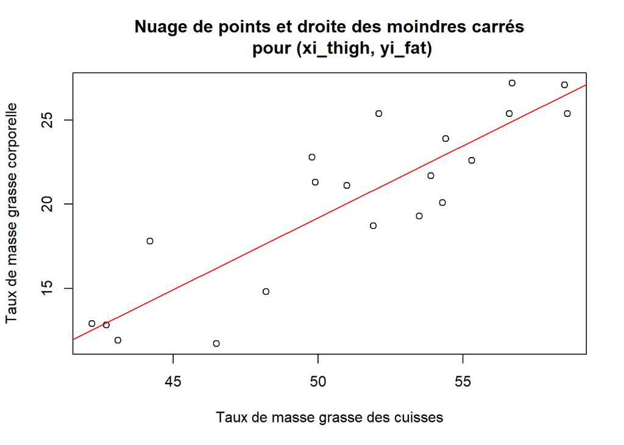

```r
plot(xi_thigh, yi_fat,
    main = "Nuage de points et droite des moindres carrés
     pour (xi_thigh, yi_fat)",
    xlab = "Taux de masse grasse des cuisses",
    ylab = "Taux de masse grasse corporelle"
)
abline(model, col = "red")
```

```r
lm_coef_a_thigh <- summary(model)$coefficients[1, 1]
print("L'estimateur calculé de a est-il égal au coefficient a de la fonction lm() ?")
```

```
## [1] "L'estimateur calculé de a est-il égal au coefficient a de la fonction lm() ?"
```

```r
all.equal(lm_coef_a_thigh, a_hat_thigh)
```

```
## [1] TRUE
```

```r
lm_coef_b_thigh <- summary(model)$coefficients[2, 1]
print("L'estimateur calculé de b est-il égal au coefficient b de la fonction lm() ?")
```

```
## [1] "L'estimateur calculé de b est-il égal au coefficient b de la fonction lm() ?"
```

```r
all.equal(lm_coef_b_thigh, b_hat_thigh)
```

```
## [1] TRUE
```

```r
e_hat_thigh <- yi_fat - (a_hat_thigh + b_hat_thigh * xi_thigh)
print("Le vecteur des résidus calculé est-il égal à celui de la fonction lm() ?")
```

```
## [1] "Le vecteur des résidus calculé est-il égal à celui de la fonction lm() ?"
```

```r
all.equal(mean(e_hat_thigh), mean(summary(model)$residuals))
```

```
## [1] TRUE
```

### (Q16) Détermination d’une estimation par intervalle de confiance de a et b.

La fonction `confint` prend en argument le model, et le niveau de confiance $1-\alpha = 0.95$. La première ligne indique l’intervalle de confiance pour le paramètre $a$. La deuxième ligne indique l’intervalle de confiance pour le paramètre $b$.

```r
confint(model, level = 0.95)
```

```
##                   2.5 %     97.5 %
## (Intercept) -35.5202742 -11.748704
## xi_thigh      0.6254123   1.087681
```

## III.3 Qualité de l’ajustement

## III.3.1 Coefficient de détermination

### (Q17) Coefficient de détermination $R²$ de la régression linéaire

Nous utilisons pour déterminer $R²$ la fonction summary de la façon suivante :

```r
print("coefficient de détermination R² :")
```

```
## [1] "coefficient de détermination R² :"
```

```r
R2 <- summary(model)[["r.squared"]]
print(R2)
```

```
## [1] 0.7710414
```

Mais nous pouvons aussi le calculer à la main :

```r
sxy <- mean((yi_fat - mean(yi_fat)) * (xi_thigh - mean(xi_thigh)))
sx2 <- mean((xi_thigh - mean(xi_thigh))^2)
sy2 <- mean((yi_fat - mean(yi_fat))^2)

R2_calcul <- (sxy^2) / ((sx2) * (sy2))
print("coefficient de détermination R² calculé :")
```

```
## [1] "coefficient de détermination R² calculé :"
```

```r
print(R2_calcul)
```

```
## [1] 0.7710414
```

Le coefifficient de determination étant beaucoup plus petit que 1, nos variables aléatoires n’appartiennent pas à la droite de régréssion linéaire. En conséquences, les prédictions réalisées par notre modèle ne seront pas valide à 100%.

### (Q18) Vérification de l’égalité entre le carré du coefficient de corrélation

### de Pearson et R² trouvé précédemment.

On affiche la différence entre le carré du coefficient de corrélation de Pearson et le coefficient de détermination $R²$ trouvé à la question précédente (Q17). On trouve une valeur très proche de 0, l’égalité est donc vérifiée. Autre manière de vérifier l’égalité : on utilise la fonction `all.equal` et elle nous renvoie TRUE.

```r
print("Différence entre le coefficient de corrélation et R2 :")
```

```
## [1] "Différence entre le coefficient de corrélation et R2 :"
```

```r
coef_cor_thigh^2 - R2
```

```
## [1] -3.330669e-16
```

```r
print("Vérification de l'égalité entre les deux avec all.equal :")
```

```
## [1] "Vérification de l'égalité entre les deux avec all.equal :"
```

```r
all.equal(R2, coef_cor_thigh^2)
```

```
## [1] TRUE
```

## III.3.2 Test de l’hypothèse H_0 : b = 0 contre H_1 : le complémentaire de H_0

### (Q19) Test si le coefficient de la pente $b$ est nul

Le coefficient de coorélation n’étant pas nul, nous pouvons confirmer l’hypothèse $H_1$ (le coefficient de la pente b n’est pas nul) ce qui nous permet de valider le modèle de régression linéaire.

```r
model$coefficients["xi_thigh"]
```

```
##  xi_thigh
## 0.8565466
```

## III.4 Validation des hypothèses

### (Q20) Évaluation visuelle de la normalité des résidus corrigés

On remarque que les résidus sont normalisés (il peut être acceptable de considérer que les résidus suivent une loi normale.)

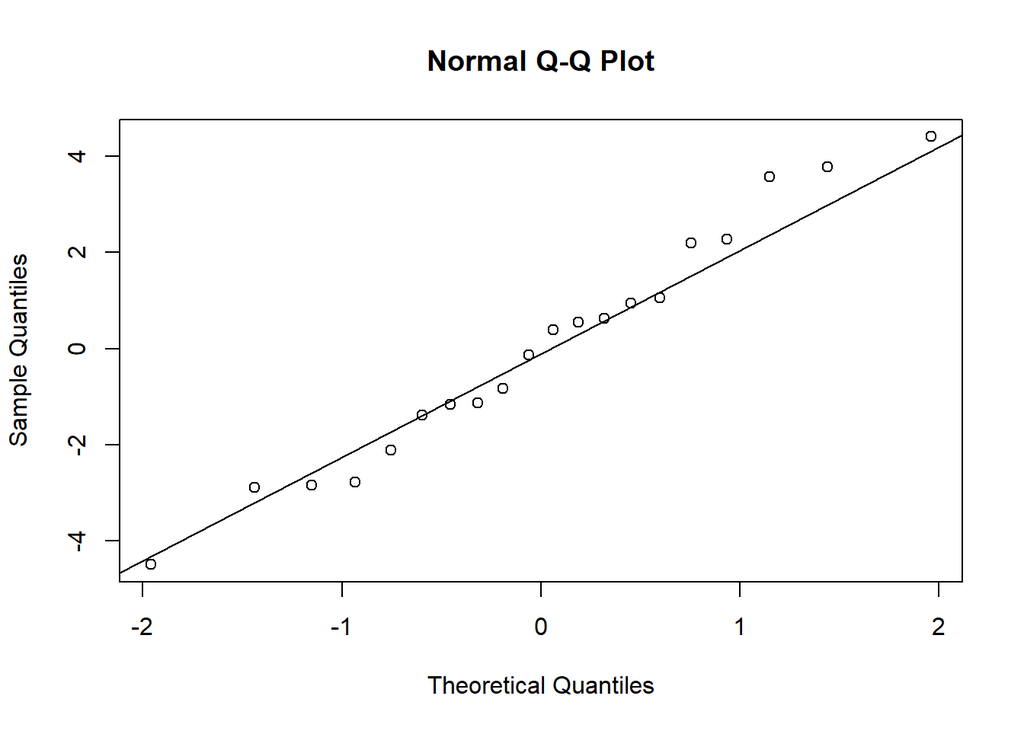

```r
# On affiche les résidus corrigés
qqnorm(summary(model)$residuals)
qqline(summary(model)$residuals)
```

### (Q21) Évaluation visuelle de l’indépendance des résidus corrigés et l’hypothèse d’homoscédasticité

On affiche l’indépendance des résidus corrigés et l’hypothèse d’homoscédasticité Les residus corrigés se repartissent le long de la droite $y=0$ et les écart des residus par rapport a cette droite restent constant le long de l’axe des abscisses.

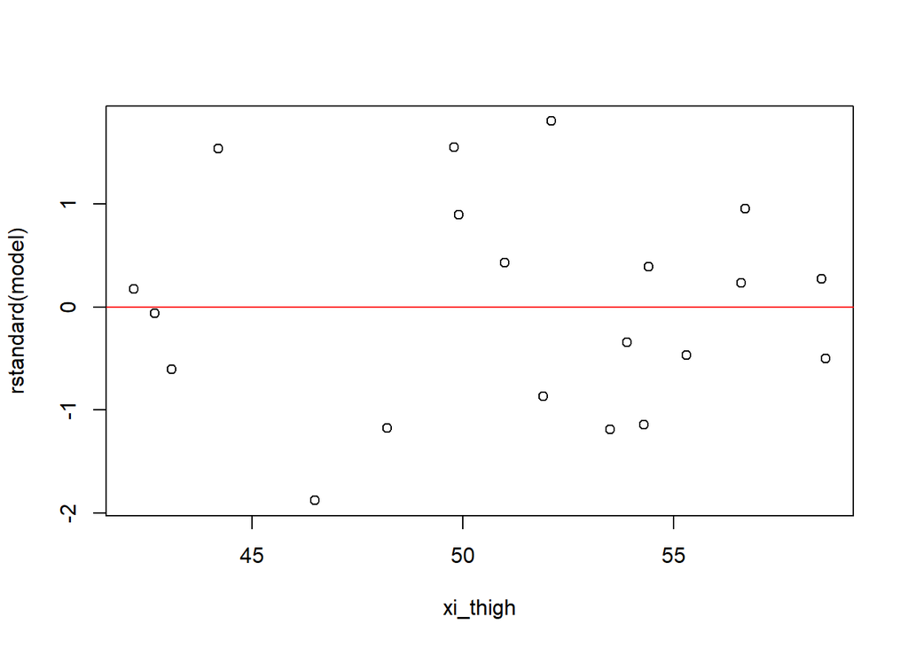

```r
plot(xi_thigh, rstandard(model))
abline(0, 0, col = "red")
```

## III.5 Prévision

### (Q22) Considérer deux nouvelles valeurs de x pour lesquelles on déterminera un intervalle de confiance pour $E(Y_0)$ au niveau 0.95 et un intervalle de prédiction au niveau 0.95.

Pour calculer l’interface de confiance et de prediction, nous utilisons la fonction `predict` de la bibliothèque `lm` qui prend en compte le parametre du modele de regression linéaire ainsi que les nouvelles valeurs de $x$ sous forme de `data.frame`.

Dans la modélisation prédictive, un intervalle de confiance peut être utilisé pour quantifier l’incertitude de la compétence estimée d’un modèle, tandis qu’un intervalle de prédiction peut être utilisé pour quantifier l’incertitude d’une seule prévision.

Un intervalle de confiance quantifie l’incertitude sur une variable de population estimée, telle que la moyenne ou l’écart-type. Alors qu’un intervalle de prédiction quantifie l’incertitude sur une seule observation estimée à partir de la population.

```r
new_data <- data.frame(xi_thigh = c(35, 60))
predict(model, new_data, interval = "confidence", level = 0.95)
```

```
##         fit      lwr      upr
## 1  6.344642  2.42557 10.26371
## 2 27.758306 25.40119 30.11542
```

```r
predict(model, new_data, interval = "prediction", level = 0.95)
```

```
##         fit        lwr      upr
## 1  6.344642 -0.2259241 12.91521
## 2 27.758306 21.9816979 33.53491
```